# Introduction to “nimble”: Bayesian linear regression

Sudipto Banerjee

2023-10-17

0. The root directory for this project has 3 subfolders: “data”, “src” and “test”. The source Rmd file is in the “test” directory. The “data” directory contains the data sets for this linear regression example. The “src” directory contains a nimble model in the “model_nimble.txt” file and an R program called “data_prep.R” to prepare the data into nimble format.
1. Remove all objects from R workspace—good programming practice and can help debug your code better.

```r
rm(list = ls())
```

2. Prepare the data by running the “data_prep.R” file in the “src” directory. When preparing the data, it is important to note that “nimble” expects the dependent random variable(s) being modeled to be stored as a separate object from the covariates and other fixed variables. So we create “nimbleData” to store the “Y” and “nimbleConstants” to store the fixed matrix of regressors “X” and other constants.

```r
source("../src/data_prep.R")
```

3. Load “nimble” and “coda” packages. Optionally, set the seed.

```r
library(nimble)
library(coda)
set.seed(1234) ##Optional
```

4. The code in “data_prep.R” creates “nimbleData” (Y), “nimbleConst” (X) and “nimbleInits”. For “nimbleInits”, apart from the different model parameters, we also initialize a variable “yFit” that represents the (posterior predictive) model-fitted distribution for each data point, i.e., “yFit[i] ~ dnorm(mu[i], tausq)” in the nimbleCode.

```r
attributes(nimbleData)
```

```
## $names
## [1] "Y"
```

```r
attributes(nimbleConstants)
```

```
## $names
## [1] "N" "p" "X"
```

```r
attributes(nimbleInits)
```

[output not shown]

We will run 3 chains in our MCMC algorithm. We will need initial values for the model parameters.

5. Set the following variables:

```r
n_iter = 11000 ## Number of iterations
n_chains = length(nimbleInits) ## Number of different chains
n_burn = 1000 ## Number of initial runs ("burn" period) for MCMC to converge.
```

6. Define the model parameters to be recognized by the nimble model

```r
model_parameters = c("beta", "tausq", "sigma", "yFit")
```

7. Read the nimble code from text file

```r
lmCode <- nimbleCode({
        for (i in 1:N) {
                Y[i] ~ dnorm(mu[i], tausq)
                mu[i] <- inprod(X[i,1:p], beta[1:p])
            yFit[i] ~ dnorm(mu[i], tausq)
    }

                for (i in 1:p) { beta[i] ~ dflat()}
                tausq ~ dgamma(0.001, 0.001)
                sigma <- 1/sqrt(tausq)

}
)
```

8. Create the nimbleModel

```r
mcmc.out <- nimbleMCMC(code = lmCode, constants=nimbleConstants, data=nimbleData, inits = nimbleInits, nchains=n_chains, niter = n_iter, nburnin=n_burn, monitor=model_parameters)
```

```
## Defining model
```

```
## Building model
```

```
## Setting data and initial values
```

```
## Running calculate on model
##   [Note] Any error reports that follow may simply reflect missing values in model variables.
```

```
## Checking model sizes and dimensions
```

```
## Checking model calculations
```

```
## Compiling
##   [Note] This may take a minute.
##   [Note] Use 'showCompilerOutput = TRUE' to see C++ compilation details.
```

```
## running chain 1...
```

```
## |-------------|-------------|-------------|-------------|
## |-------------------------------------------------------|
```

```
## running chain 2...
```

```
## |-------------|-------------|-------------|-------------|
## |-------------------------------------------------------|
```

```
## running chain 3...
```

```
## |-------------|-------------|-------------|-------------|
## |-------------------------------------------------------|
```

9. Attributes of mcmc.out

```r
attributes(mcmc.out)
```

```
## $names
## [1] "chain1" "chain2" "chain3"
```

10. Extract posterior samples:

```r
samps <- rbind(mcmc.out$chain1, mcmc.out$chain2, mcmc.out$chain3)
dim(samps)
```

```
## [1] 30000    62
```

13. Obtain medians and 95% credible intervals for these samples

```r
credibleIntervals <- t(apply(samps, 2, function(x){quantile(x, c(0.50, 0.025, 0.975))}))
```

14. Extract credible intervals for specific variable(s):

```r
CI_beta <- credibleIntervals[grep("beta", rownames(credibleIntervals)),]
CI_beta
```

```
##               50%       2.5%    97.5%
## beta[1] 26.189964 19.3610391 33.23632
## beta[2]  1.341464  0.8765314  1.79018
```

```r
CI_sigma <- credibleIntervals[grep("sigma", rownames(credibleIntervals)),]
CI_sigma
```

```
##      50%     2.5%    97.5%
## 7.405845 6.207211 9.045783
```

```r
CI_yFit <- credibleIntervals[grep("yFit", rownames(credibleIntervals)),]
CI_yFit
```

```
##               50%     2.5%    97.5%
## yFit[1]  41.60444 26.82512 56.57606
## yFit[2]  42.99139 28.25559 57.97966
## yFit[3]  43.06501 28.11308 58.05121
## yFit[4]  47.58161 32.53052 62.35331
## yFit[5]  43.07938 28.26832 58.05398
## yFit[6]  51.54509 36.50253 66.32733
## yFit[7]  43.10928 28.26502 58.21286
## yFit[8]  59.29120 43.79337 74.80033
## yFit[9]  47.61672 32.66770 62.44983
## yFit[10] 51.72635 36.69875 66.69004
## yFit[11] 51.55488 36.66663 66.56491
## yFit[12] 45.48946 30.77860 60.39325
## yFit[13] 39.86908 24.98294 55.07502
## yFit[14] 43.03716 28.06720 57.97779
## yFit[15] 46.00649 31.07109 60.89665
## yFit[16] 44.84660 29.98380 59.77765
## yFit[17] 60.42683 44.80133 76.21083
## yFit[18] 46.65365 31.67542 61.58826
## yFit[19] 41.73216 26.99760 56.66280
## yFit[20] 40.39916 25.52910 55.42834
## yFit[21] 38.14203 23.15036 53.55347
## yFit[22] 51.91715 37.02833 67.07829
## yFit[23] 46.19070 31.32711 61.25663
## yFit[24] 48.25990 33.41080 63.22443
## yFit[25] 46.78792 31.49324 61.66224
## yFit[26] 43.05703 28.16824 58.07991
## yFit[27] 40.37127 25.32923 55.81237
## yFit[28] 47.16885 32.10349 62.08155
## yFit[29] 46.77646 31.86370 61.58264
## yFit[30] 41.10620 26.27910 55.92541
## yFit[31] 38.32306 22.92058 53.68796
## yFit[32] 46.75377 31.82930 61.59573
## yFit[33] 41.99620 27.01012 56.88974
## yFit[34] 47.56741 32.69250 62.65688
## yFit[35] 40.25540 25.39996 55.42635
## yFit[36] 44.61921 29.87675 59.68218
## yFit[37] 40.93738 25.98121 56.01763
## yFit[38] 40.69818 25.50043 55.68086
## yFit[39] 44.68369 29.88480 59.61844
## yFit[40] 43.56886 28.64934 58.34604
## yFit[41] 35.20147 19.83027 50.54904
## yFit[42] 41.00884 26.17196 55.92844
## yFit[43] 37.81146 22.68726 53.01696
## yFit[44] 40.27840 25.27943 55.11104
## yFit[45] 53.81763 38.64873 69.03979
## yFit[46] 46.62481 31.82650 61.55134
## yFit[47] 59.30161 43.65367 74.83842
## yFit[48] 41.66021 26.69863 56.63209
## yFit[49] 43.28289 28.37843 58.37202
## yFit[50] 48.33606 33.34045 63.40072
## yFit[51] 46.25696 31.34654 61.06096
## yFit[52] 51.53544 36.38560 66.71469
## yFit[53] 59.23470 43.58606 74.63128
## yFit[54] 48.83653 34.05115 63.88130
## yFit[55] 51.97719 36.86352 67.05872
## yFit[56] 40.18549 25.29678 55.05386
## yFit[57] 41.63829 26.63549 56.58895
## yFit[58] 56.10557 40.83848 71.18556
```

15. We will now draw samples from the data replicated distributions. First collect the posterior samples of “beta” and “sigma”

```r
    betaSamps <- samps[,1:p]
    sigmaSamps <- samps[,(p+1)]
    yFitSamps <- samps[,(p+3):ncol(samps)]
```

16. Rather than define “yFit” in the nimbleCode, we can also draw data replicates from the posterior predictive distribution directly in R using the following code. The matrix “yRep” below consists of the posterior predictive samples.

```r
    muRep <- matrix(tcrossprod(betaSamps, X), ncol=1)
    yRep <- rnorm(nrow(betaSamps)*N, muRep, rep(sigmaSamps, times=N))
    yRep <- matrix(yRep, ncol=58)
    CI_yRep <- t(apply(yRep, 2, function(x){quantile(x, c(0.50, 0.025, 0.975))}))
```

17. The distribution of “yFit” and “yRep” should be the same so the only differences between their values are due to Monte Carlo sampling. Compare inference using “yFitSamps” with “yRep”. Plot posterior predictive medians of yFit and yRep.

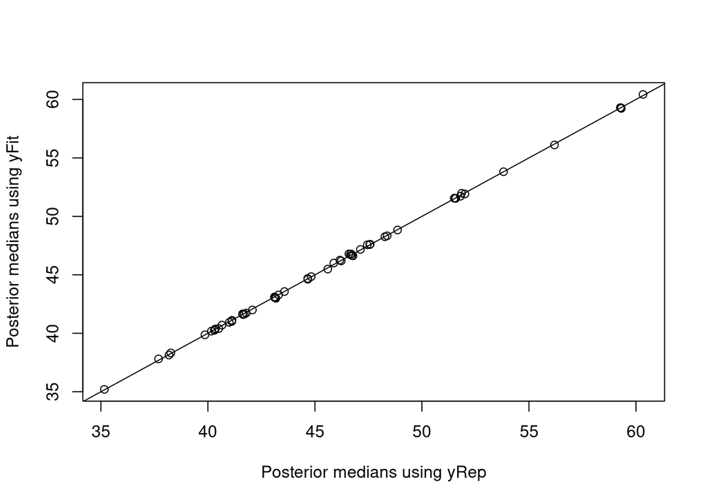

```r
plot(CI_yRep[,grep("50%", colnames(CI_yRep))], CI_yFit[,grep("50%", colnames(CI_yFit))], xlab="Posterior medians using yRep", ylab="Posterior medians using yFit")
abline(0,1)
```

18. Plot posterior predictive quantiles from these two objects:

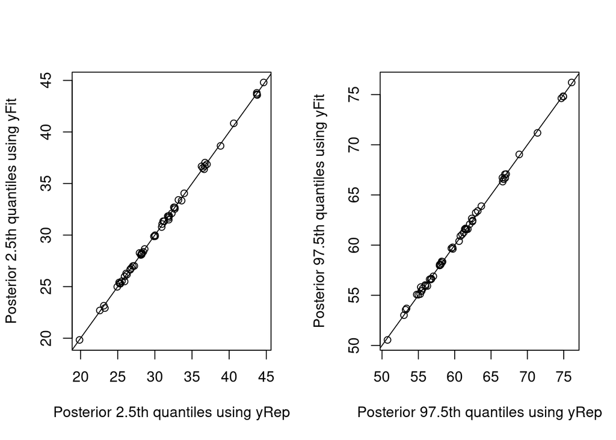

```r
par(mfrow=c(1,2))
plot(CI_yRep[,grep("2.5%", colnames(CI_yRep))], CI_yFit[,grep("2.5%", colnames(CI_yFit))], xlab="Posterior 2.5th quantiles using yRep", ylab="Posterior 2.5th quantiles using yFit")
abline(0,1)
plot(CI_yRep[,grep("97.5%", colnames(CI_yRep))], CI_yFit[,grep("97.5%", colnames(CI_yFit))], xlab="Posterior 97.5th quantiles using yRep", ylab="Posterior 97.5th quantiles using yFit")
abline(0,1)
```

19. You can also do qqplots for the model-fitted values for any county. We do this for counties 1, 37 and 58 (just as examples).

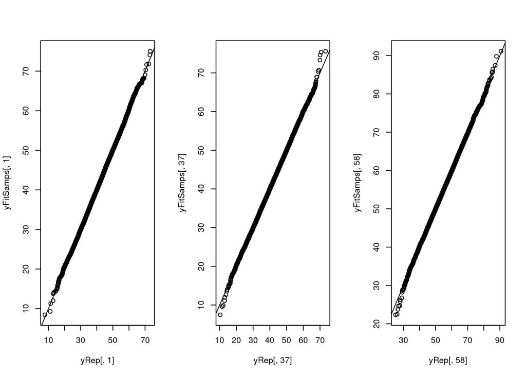

```r
par(mfrow=c(1,3))
qqplot(yRep[,1], yFitSamps[,1])
abline(0,1)
qqplot(yRep[,37], yFitSamps[,37])
abline(0,1)
qqplot(yRep[,58], yFitSamps[,58])
abline(0,1)
```

Now that we have convinced ourselves that yFit and yRep are pretty much indistinguishable, we can just use one of these methods.

20. We can define a goodness of fit measure “G” using yFit (or yRep).

```r
G <- sum((Y - colMeans(yFitSamps))^2)
G
```

```
## [1] 3023.201
```

21. We can also define a measure of penalty “P” using yFit (or yRep).

```r
P <- sum(apply(yFitSamps, 2, function (x) {var(x)} ))
P
```

```
## [1] 3380.923
```

22. Finally, we can use a score “D=G+P” for this model. This score is useful for model comparisons. The smaller the score, the better the model.

```r
D <- G+P
D
```

```
## [1] 6404.124
```

23. Until now we have used a quick route to fitting a linear model in nimble. We will now demonstrate a more systematic route to compile and build a nimble program and then run the MCMC. reate the “nimbleModel” object. Compile it and configure the MCMC

```r
rModel <- nimbleModel(code=lmCode, name="lm_simple", constants=nimbleConstants, data=nimbleData)
```

```
## Defining model
```

```
## Building model
```

```
## Setting data and initial values
```

```
## Running calculate on model
##   [Note] Any error reports that follow may simply reflect missing values in model variables.
```

```
## Checking model sizes and dimensions
```

```
##   [Note] This model is not fully initialized. This is not an error.
##          To see which variables are not initialized, use model$initializeInfo().
##          For more information on model initialization, see help(modelInitialization).
```

```r
cModel <- compileNimble(rModel)
```

```
## Compiling
##   [Note] This may take a minute.
##   [Note] Use 'showCompilerOutput = TRUE' to see C++ compilation details.
```

```r
conf <- configureMCMC(rModel, monitors=model_parameters)
```

```
## ===== Monitors =====
## thin = 1: beta, sigma, tausq, yFit
## ===== Samplers =====
## posterior_predictive sampler (58)
##   - yFit[]  (58 elements)
## conjugate sampler (3)
##   - beta[]  (2 elements)
##   - tausq
```

```r
MCMC <- buildMCMC(conf)
cMCMC <- compileNimble(MCMC, project = cModel)
```

```
## Compiling
##   [Note] This may take a minute.
##   [Note] Use 'showCompilerOutput = TRUE' to see C++ compilation details.
```

24. Next we run the MCMC and combine the output from the 3 chains into a single matrix whose columns will include the posterior samples corresponding to each parameter.

```r
samps <- runMCMC(cMCMC, inits=nimbleInits, nchains=length(nimbleInits), niter=n_iter, nburnin = n_burn, samplesAsCodaMCMC = TRUE)
```

```
## running chain 1...
```

```
## |-------------|-------------|-------------|-------------|
## |-------------------------------------------------------|
```

```
## running chain 2...
```

```
## |-------------|-------------|-------------|-------------|
## |-------------------------------------------------------|
```

```
## running chain 3...
```

```
## |-------------|-------------|-------------|-------------|
## |-------------------------------------------------------|
```

```r
samps <- do.call(rbind, samps)
```

25. Obtain medians and 95% credible intervals for the model parameters from these samples

```r
credibleIntervals <- t(apply(samps, 2, function(x){quantile(x, c(0.50, 0.025, 0.975))}))
```

26. Extract medians and 95% credible intervals for specific model parameters.

```r
CI_beta <- credibleIntervals[grep("beta", rownames(credibleIntervals)),]
CI_beta
```

```
##               50%       2.5%     97.5%
## beta[1] 26.104262 19.3994026 33.307576
## beta[2]  1.346616  0.8749967  1.795015
```

```r
CI_sigma <- credibleIntervals[grep("sigma", rownames(credibleIntervals)),]
CI_sigma
```

```
##      50%     2.5%    97.5%
## 7.395359 6.212932 8.981566
```

```r
CI_yFit <- credibleIntervals[grep("yFit", rownames(credibleIntervals)),]
## CI_yFit ##Uncomment to see posterior credible intervals of all fitted values.
```

27. Get all posterior samples of yFit.

```r
yFitSamps <- samps[,grep("yFit", colnames(samps))]
```

28. Compute a goodness-of-fit measure.

```r
G <- sum((Y - colMeans(yFitSamps))^2)
G
```

```
## [1] 3031.508
```

28. Compute a measure of penalty.

```r
P <- sum(apply(yFitSamps, 2, function (x) {var(x)} ))
P
```

```
## [1] 3362.075
```

29. Compute the model score “D=G+P” for this model. This score is useful for model comparisons. The smaller the score, the better the model.

```r
D <- G + P
D
```

```
## [1] 6393.584
```